# R 01

```r
library(MASS)
data(Cars93)
attach(Cars93)
```

# Frequency tables, pie charts and bar charts

Frequency table

```r
table(Type)
```

```
Type
Compact   Large Midsize   Small  Sporty     Van
     16      11      22      21      14       9
```

```r
freq.tb.Type <- table(Type)
freq.tb.Type
```

```
Type
Compact   Large Midsize   Small  Sporty     Van
     16      11      22      21      14       9
```

Relative frequency table

```r
n <- length(Type)
rel.freq.tb.Type <- freq.tb.Type/n
rel.freq.tb.Type
```

```
Type
   Compact      Large    Midsize      Small     Sporty        Van
0.17204301 0.11827957 0.23655914 0.22580645 0.15053763 0.09677419
```

```r
round(rel.freq.tb.Type, digits=2)
```

```
Type
Compact   Large Midsize   Small  Sporty     Van
   0.17    0.12    0.24    0.23    0.15    0.10
```

Pie chart

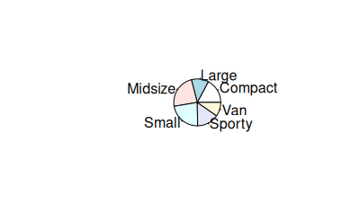

```r
pie(freq.tb.Type)
```

Bar chart

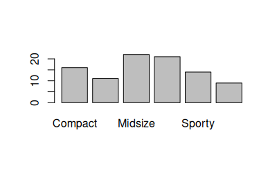

```r
barplot(freq.tb.Type)
```

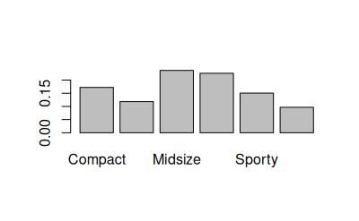

```r
barplot(rel.freq.tb.Type)
```

More than one variable:

```r
tb.Origin.Type <- table(Origin, Type)
tb.Origin.Type
```

```
         Type
Origin    Compact Large Midsize Small Sporty Van
  USA           7    11      10     7      8   5
  non-USA       9     0      12    14      6   4
```

```r
tb.Origin.Type['USA', 'Large']
```

```
[1] 11
```

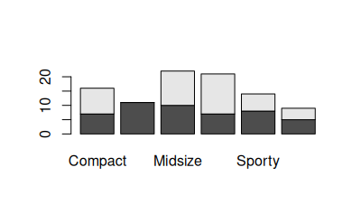

```r
barplot(tb.Origin.Type)
```

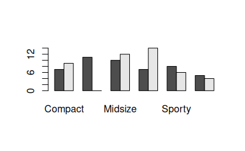

```r
barplot(tb.Origin.Type, beside=TRUE)
```

Add a legend

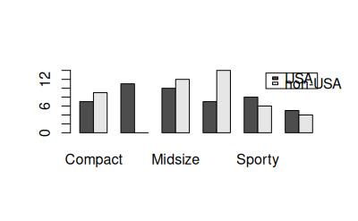

```r
barplot(tb.Origin.Type, beside=TRUE, legend=TRUE)
```

# Histograms

```r
Rear.seat.room.cm <- Rear.seat.room * 2.54
hist(Rear.seat.room.cm)
```

[output not shown]

Making the histogram look nicer: arguments xlab, ylab, main and col

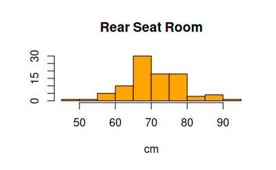

```r
hist(Rear.seat.room.cm, xlab='cm', ylab='', main='Rear Seat Room', col='orange')
```

It may be convenient to define graphical parameters (such as text options) of a plotting function as variables to be used in all instances of function.

```r
rsr     <- 'Rear Seat Room'
rsr.x   <- 'cm'
rsr.y   <- ''
rsr.col <- 'orange'
```

Function `par()` to split graphic panel and specify number of bins: argument breaks.

```r
par(mfrow=c(1,2))

hist(Rear.seat.room.cm, xlab=rsr.x, ylab=rsr.y,  main=rsr, col=rsr.col)

hist(Rear.seat.room.cm, breaks=30, xlab=rsr.x, ylab=rsr.y,  main=rsr, col=rsr.col)
```

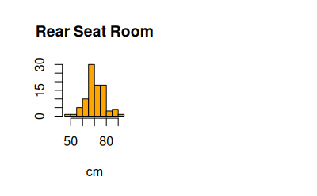

```r
par(mfrow=c(1,1))
```

Density vs frequency histogram: two equivalent ways to produce a density histogram.

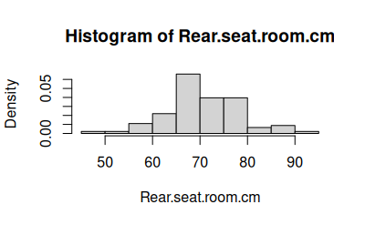

```r
hist(Rear.seat.room.cm, freq=FALSE)
```

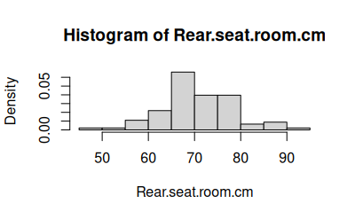

```r
hist(Rear.seat.room.cm, probability=TRUE)
```

Specify the endpoints of the class intervals: function `range` and argument `na.rm`

```r
range(Rear.seat.room.cm)
```

```
[1] NA NA
```

```r
range(Rear.seat.room.cm, na.rm=TRUE)
```

```
[1] 48.26 91.44
```

Compare the histogram under four conditions:  
1. equispaced vs non-equispaced bins  
2. frequency vs density histogram

```r
bins <- c(48, 65, 70, 75,  92)

par(mfrow=c(2,2))

hist(Rear.seat.room.cm,
     freq=FALSE,
     main='density/equispaced',
     xlab='',
     ylab='',
     col=rsr.col)

hist(Rear.seat.room.cm,
     freq=TRUE,
     main='frequency/equispaced',
     xlab='',
     ylab='',
     col=rsr.col)
```

[figure not shown]

```r
hist(Rear.seat.room.cm,
     freq=FALSE,
     breaks=bins,
     main='density/non-equispaced',
     xlab='',
     ylab='',
     col=rsr.col)

hist(Rear.seat.room.cm,
     freq=TRUE,
     breaks=bins,
     main='frequency/non-equispaced',
     xlab='',
     ylab='',
     col=rsr.col)
par(mfrow=c(1,1))
```

[output not shown]

Output of the function `hist()`:

```r
hist(Rear.seat.room.cm)
```

[output not shown]

```r
h <- hist(Rear.seat.room.cm)
```

```r
h
```

```
$breaks
 [1] 45 50 55 60 65 70 75 80 85 90 95

$counts
 [1]  1  1  5 10 30 18 18  3  4  1

$density
 [1] 0.002197802 0.002197802 0.010989011 0.021978022 0.065934066 0.039560440 0.039560440 0.006593407 0.008791209 0.002197802

$mids
 [1] 47.5 52.5 57.5 62.5 67.5 72.5 77.5 82.5 87.5 92.5

$xname
[1] "Rear.seat.room.cm"

$equidist
[1] TRUE

attr(,"class")
[1] "histogram"
```

```r
is.list(h)
```

```
[1] TRUE
```

```r
h$counts
```

```
 [1]  1  1  5 10 30 18 18  3  4  1
```

```r
h[[2]]
```

```
 [1]  1  1  5 10 30 18 18  3  4  1
```

```r
class(h)
```

```
[1] "histogram"
```

The generic function `plot()` has a specific method for objects of class ‘histogram’:

```r
plot(h)
```

[output not shown]

# Density Plot

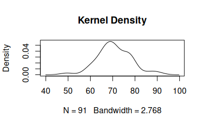

```r
dens <- density(Rear.seat.room.cm, na.rm=TRUE) # kernel estimation of the density
plot(dens, main='Kernel Density') # plot the estimate
```

Compare density plot with histogram

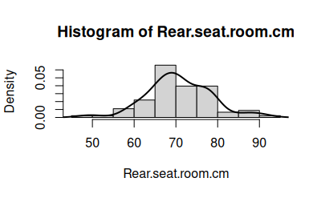

```r
hist(Rear.seat.room.cm, freq=FALSE)
lines(dens, lwd=2)
```

Change the bandwidth

```r
dens0.5 <- density(Rear.seat.room.cm, adjust=0.5, na.rm=TRUE)

hist(Rear.seat.room.cm, freq=FALSE)
lines(dens0.5, col='red',  lwd=2)
```

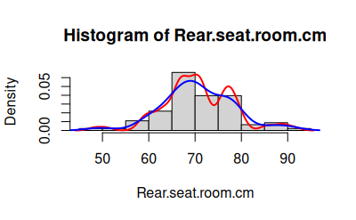

```r
lines(dens, col='blue', lwd=2)
```

Take a look at the object `dens`

```r
class(dens)
```

```
[1] "density"
```

```r
is.list(dens)
```

```
[1] TRUE
```

```r
dens$x[1:10]
```

```
 [1] 39.95491 40.07192 40.18892 40.30593 40.42293 40.53994 40.65695 40.77395 40.89096 41.00797
```

```r
dens$y[1:10]
```

```
 [1] 1.837760e-05 2.090399e-05 2.372946e-05 2.683941e-05 3.026473e-05 3.421582e-05 3.854966e-05 4.328557e-05 4.855043e-05 5.447490e-05
```

# Numerical Summaries

Arithmetic mean

```r
mean(Rear.seat.room.cm)
```

```
[1] NA
```

```r
mean(Rear.seat.room.cm, na.rm=TRUE)
```

```
[1] 70.68736
```

Removing NA’s

```r
# using the function is.na()
is.na(Rear.seat.room.cm)
```

```
 [1] FALSE FALSE FALSE FALSE FALSE FALSE FALSE FALSE FALSE FALSE FALSE FALSE FALSE FALSE FALSE FALSE FALSE FALSE  TRUE FALSE FALSE FALSE FALSE FALSE FALSE FALSE FALSE
[28] FALSE FALSE FALSE FALSE FALSE FALSE FALSE FALSE FALSE FALSE FALSE FALSE FALSE FALSE FALSE FALSE FALSE FALSE FALSE FALSE FALSE FALSE FALSE FALSE FALSE FALSE FALSE
[55] FALSE FALSE  TRUE FALSE FALSE FALSE FALSE FALSE FALSE FALSE FALSE FALSE FALSE FALSE FALSE FALSE FALSE FALSE FALSE FALSE FALSE FALSE FALSE FALSE FALSE FALSE FALSE
[82] FALSE FALSE FALSE FALSE FALSE FALSE FALSE FALSE FALSE FALSE FALSE FALSE
```

```r
Rear.seat.room.cm[!is.na(Rear.seat.room.cm)]
```

```
 [1] 67.31 76.20 71.12 78.74 68.58 71.12 77.47 77.47 67.31 88.90 78.74 63.50 66.04 63.50 72.39 77.47 85.09 74.93 78.74 77.47 91.44 67.31 67.31 77.47 67.31 77.47 50.80
[28] 67.31 76.20 66.04 71.12 69.85 60.96 58.42 76.20 69.85 76.20 69.85 62.23 59.69 71.12 71.12 66.04 71.12 59.69 78.74 73.66 69.85 63.50 76.20 80.01 68.58 67.31 74.93
[55] 69.85 66.04 68.58 48.26 71.12 66.04 69.85 66.04 72.39 68.58 72.39 71.12 71.12 77.47 80.01 62.23 64.77 63.50 63.50 72.39 77.47 67.31 67.31 59.69 69.85 68.58 69.85
[82] 60.96 58.42 72.39 88.90 66.04 86.36 80.01 66.04 74.93 76.20
```

```r
# using the function na.omit()
na.omit(Rear.seat.room.cm)
```

```
 [1] 67.31 76.20 71.12 78.74 68.58 71.12 77.47 77.47 67.31 88.90 78.74 63.50 66.04 63.50 72.39 77.47 85.09 74.93 78.74 77.47 91.44 67.31 67.31 77.47 67.31 77.47 50.80
[28] 67.31 76.20 66.04 71.12 69.85 60.96 58.42 76.20 69.85 76.20 69.85 62.23 59.69 71.12 71.12 66.04 71.12 59.69 78.74 73.66 69.85 63.50 76.20 80.01 68.58 67.31 74.93
[55] 69.85 66.04 68.58 48.26 71.12 66.04 69.85 66.04 72.39 68.58 72.39 71.12 71.12 77.47 80.01 62.23 64.77 63.50 63.50 72.39 77.47 67.31 67.31 59.69 69.85 68.58 69.85
[82] 60.96 58.42 72.39 88.90 66.04 86.36 80.01 66.04 74.93 76.20
attr(,"na.action")
[1] 19 57
attr(,"class")
[1] "omit"
```

```r
Rear.seat.room.cm.cleaned <- na.omit(Rear.seat.room.cm)
```

Deviations from mean

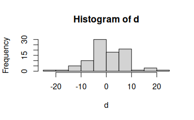

```r
bar.x <- mean(Rear.seat.room.cm.cleaned)
d <- Rear.seat.room.cm.cleaned - bar.x

# Check that deviations from the mean are centered about zero
hist(d)
```

```r
sum(d)
```

```
[1] -9.237056e-14
```

Median

```r
median(Rear.seat.room.cm.cleaned)
```

```
[1] 69.85
```

```r
sort(Rear.seat.room.cm.cleaned)[46]
```

```
[1] 69.85
```

Arithmetic mean is highly sensitive to data points that are significantly different from the rest of the dataset, either much larger or much smaller.

```r
data.points <- 1:10
data.points
```

```
 [1]  1  2  3  4  5  6  7  8  9 10
```

```r
mean(data.points)
```

```
[1] 5.5
```

```r
median(data.points)
```

```
[1] 5.5
```

```r
data.points[10] <- 100
data.points
```

```
 [1]   1   2   3   4   5   6   7   8   9 100
```

```r
mean(data.points)
```

```
[1] 14.5
```

```r
median(data.points)
```

```
[1] 5.5
```

```r
data.points[10] <- 1000
data.points
```

```
 [1]    1    2    3    4    5    6    7    8    9 1000
```

```r
mean(data.points)
```

```
[1] 104.5
```

```r
median(data.points)
```

```
[1] 5.5
```

Variance and standard deviation

```r
x <- Rear.seat.room.cm.cleaned
s2 <- sum((x-mean(x))^2)/(length(x)-1)
var(x)
```

```
[1] 57.64217
```

```r
sd(x)
```

```
[1] 7.592244
```

```r
sqrt(s2)
```

```
[1] 7.592244
```

Quantiles

```r
quantile(Rear.seat.room.cm.cleaned, 0.3)
```

```
  30%
67.31
```

```r
quantile(Rear.seat.room.cm.cleaned, c(0.3, 0.6))
```

```
  30%   60%
67.31 71.12
```

```r
quantile(Rear.seat.room.cm.cleaned)
```

```
   0%   25%   50%   75%  100%
48.26 66.04 69.85 76.20 91.44
```

```r
# Interquartile range
IQR(Rear.seat.room.cm.cleaned)
```

```
[1] 10.16
```

```r
# Five-number summary (and mean)
summary(Rear.seat.room.cm.cleaned)
```

```
   Min. 1st Qu.  Median    Mean 3rd Qu.    Max.
  48.26   66.04   69.85   70.69   76.20   91.44
```

# Scatterplots and Boxplots

Boxplot

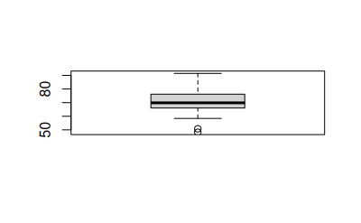

```r
boxplot(Rear.seat.room.cm.cleaned)
```

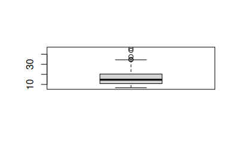

```r
boxplot(Min.Price)
```

Side-by-side boxplots

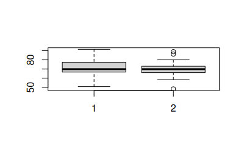

```r
Rear.seat.USA     <- Rear.seat.room.cm.cleaned[Origin=='USA']
Rear.seat.non.USA <- Rear.seat.room.cm.cleaned[Origin=='non-USA']

boxplot(Rear.seat.USA, Rear.seat.non.USA)
```

Model formula syntax

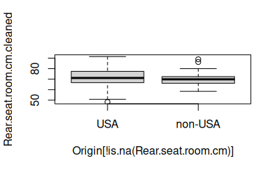

```r
boxplot(Rear.seat.room.cm.cleaned ~ Origin[!is.na(Rear.seat.room.cm)])
```

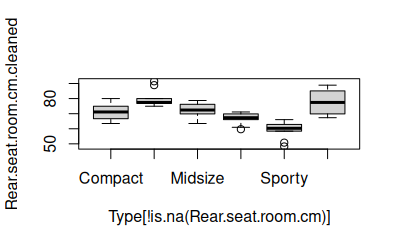

```r
boxplot(Rear.seat.room.cm.cleaned~Type[!is.na(Rear.seat.room.cm)])
```

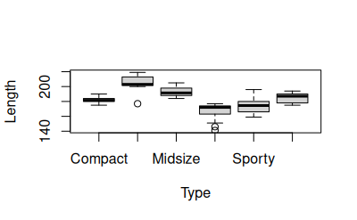

```r
boxplot(Length~Type)
```

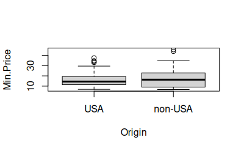

```r
boxplot(Min.Price~Origin)
```

```r
detach(Cars93)
```

‘Old faithful’ data and scatterplots

```r
data('faithful')
attach(faithful)
```

EDA of waiting time

```r
summary(waiting)
```

```
   Min. 1st Qu.  Median    Mean 3rd Qu.    Max.
   43.0    58.0    76.0    70.9    82.0    96.0
```

```r
par(mfrow=c(1, 2))
hist(waiting, col='orange', freq=FALSE, main='')
boxplot(waiting, col='lightgray')
```

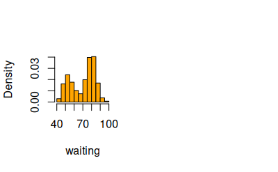

```r
par(mfrow=c(1,1))
```

EDA of eruption duration

```r
summary(eruptions)
```

```
   Min. 1st Qu.  Median    Mean 3rd Qu.    Max.
  1.600   2.163   4.000   3.488   4.454   5.100
```

```r
par(mfrow=c(1, 2))
hist(eruptions, col='orange', prob=TRUE, main='')
boxplot(eruptions, col='lightgray')
```

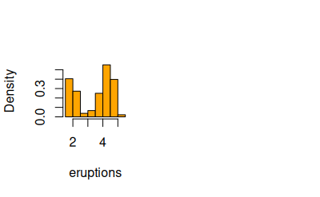

```r
par(mfrow=c(1,1))
```

```r
summary(faithful)
```

```
   eruptions        waiting
 Min.   :1.600   Min.   :43.0
 1st Qu.:2.163   1st Qu.:58.0
 Median :4.000   Median :76.0
 Mean   :3.488   Mean   :70.9
 3rd Qu.:4.454   3rd Qu.:82.0
 Max.   :5.100   Max.   :96.0
```

Scatterplots: function `plot()`

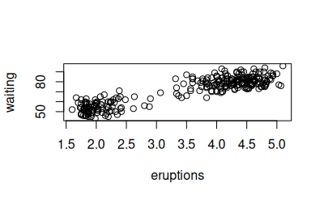

```r
plot(eruptions, waiting)
```

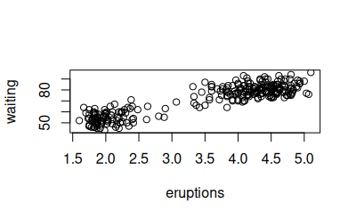

```r
plot(waiting ~ eruptions)
```

Function `plot()`, choice of symbol: argument pch

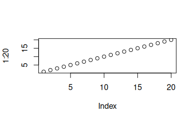

```r
plot(1:20)
```

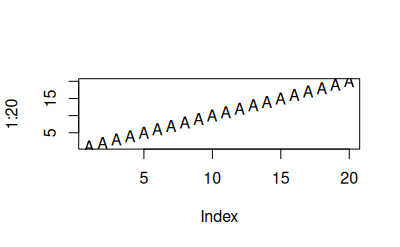

```r
plot(1:20, pch='A')
```

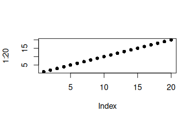

```r
plot(1:20, pch=16)
```

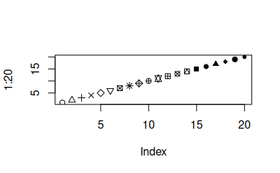

```r
plot(1:20, pch=1:20)
```

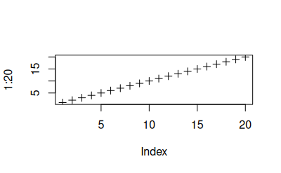

```r
plot(1:20, pch=3)
```

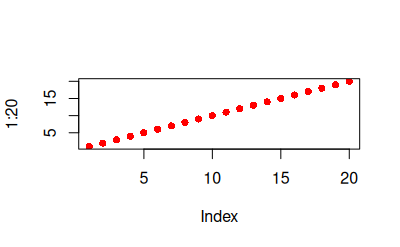

```r
# Function plot(), choice of symbol: argument col
plot(1:20, col='red', pch=16)
```

```r
colors()
```

```
  [1] "white"                "aliceblue"            "antiquewhite"         "antiquewhite1"        "antiquewhite2"        "antiquewhite3"        "antiquewhite4"
  [8] "aquamarine"           "aquamarine1"          "aquamarine2"          "aquamarine3"          "aquamarine4"          "azure"                "azure1"
 [15] "azure2"               "azure3"               "azure4"               "beige"                "bisque"               "bisque1"              "bisque2"
 [22] "bisque3"              "bisque4"              "black"                "blanchedalmond"       "blue"                 "blue1"                "blue2"
 [29] "blue3"                "blue4"                "blueviolet"           "brown"                "brown1"               "brown2"               "brown3"
 [36] "brown4"               "burlywood"            "burlywood1"           "burlywood2"           "burlywood3"           "burlywood4"           "cadetblue"
 [43] "cadetblue1"           "cadetblue2"           "cadetblue3"           "cadetblue4"           "chartreuse"           "chartreuse1"          "chartreuse2"
 [50] "chartreuse3"          "chartreuse4"          "chocolate"            "chocolate1"           "chocolate2"           "chocolate3"           "chocolate4"
 [57] "coral"                "coral1"               "coral2"               "coral3"               "coral4"               "cornflowerblue"       "cornsilk"
 [64] "cornsilk1"            "cornsilk2"            "cornsilk3"            "cornsilk4"            "cyan"                 "cyan1"                "cyan2"
 [71] "cyan3"                "cyan4"                "darkblue"             "darkcyan"             "darkgoldenrod"        "darkgoldenrod1"       "darkgoldenrod2"
 [78] "darkgoldenrod3"       "darkgoldenrod4"       "darkgray"             "darkgreen"            "darkgrey"             "darkkhaki"            "darkmagenta"
 [85] "darkolivegreen"       "darkolivegreen1"      "darkolivegreen2"      "darkolivegreen3"      "darkolivegreen4"      "darkorange"           "darkorange1"
 [92] "darkorange2"          "darkorange3"          "darkorange4"          "darkorchid"           "darkorchid1"          "darkorchid2"          "darkorchid3"
 [99] "darkorchid4"          "darkred"              "darksalmon"           "darkseagreen"         "darkseagreen1"        "darkseagreen2"        "darkseagreen3"
```

[output cut: 79 more lines]

Final scatterplot

```r
lx <- 'Eruption time (min)'
ly <- 'Waiting time to next eruption (min)'
lmain <- 'faithful data: Eruptions of Old Faithful'

plot(eruptions, waiting, xlab=lx, ylab=ly, main=lmain, pch='+')

# LOESS=LOcally Estimated Scatterplot Smoothing
int.line <- loess.smooth(eruptions, waiting, span=2/3) # span=2/3 is the default value
lines(int.line,  col='blue', lty=1, lwd=2)
```

```r
int.line # this is a list with the x and y values
```

```
$x
 [1] 1.600000 1.671429 1.742857 1.814286 1.885714 1.957143 2.028571 2.100000 2.171429 2.242857 2.314286 2.385714 2.457143 2.528571 2.600000 2.671429 2.742857 2.814286
[19] 2.885714 2.957143 3.028571 3.100000 3.171429 3.242857 3.314286 3.385714 3.457143 3.528571 3.600000 3.671429 3.742857 3.814286 3.885714 3.957143 4.028571 4.100000
[37] 4.171429 4.242857 4.314286 4.385714 4.457143 4.528571 4.600000 4.671429 4.742857 4.814286 4.885714 4.957143 5.028571 5.100000

$y
 [1] 49.57225 50.39817 51.21898 52.04546 52.88741 53.73418 54.58211 55.43449 56.29372 57.15701 58.02340 58.89250 59.76390 60.63719 61.51197 62.38781 63.26432 64.14108
[19] 65.01769 65.89374 66.76882 67.64253 68.51444 69.38417 70.25129 71.13365 72.06403 73.01820 73.96933 74.89059 75.75517 76.53623 77.20694 77.74047 78.17790 78.61594
[37] 79.04751 79.46408 79.87232 80.27813 80.67995 81.07431 81.46440 81.85617 82.24135 82.61860 82.99111 83.36208 83.73471 84.11221
```

```r
# smoother curve: span=2
int.line.2 <- loess.smooth(eruptions, waiting, span=2)
lines(int.line.2,  col='red', lty=2, lwd=2)

# rougher curve: span=1/5
int.line.0.20 <- loess.smooth(eruptions, waiting, span=1/5)
lines(int.line.0.20,  col='violet', lty=4, lwd=4)
```

```r
# Add a legend
legend(x=1.5, y=95,
       legend=c('smoothing=1/5','smoothing=2/3', 'smoothing=2'),
       col=c('violet', 'blue', 'red'),
       lty=c(4,2,1),
       lwd=c(4,2,2)
       )

# Alternative way for legend position
# 'bottomright', 'bottom', 'bottomleft', 'left',
# 'topleft', 'top', 'topright', 'right',  'center'
legend('topleft', y=NULL,
       legend=c('smoothing=1/5','smoothing=2/3', 'smoothing=2'),
       col=c('violet', 'blue', 'red'),
       lty=c(4,2,1),
       lwd=c(4,2,2)
       )
```

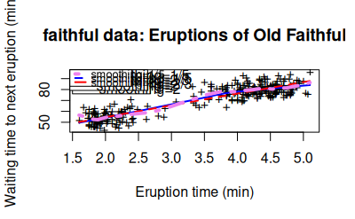

```r
# size of the legend
legend('topleft', , y=NULL, cex=0.8,
       legend=c('smoothing=1/5','smoothing=2/3', 'smoothing=2'),
       col=c('violet', 'blue', 'red'),
       lty=c(4,2,1),
       lwd=c(4,2,2)
       )
```

`scatter.smooth()` function: `loess.smooth()`+`plot()`

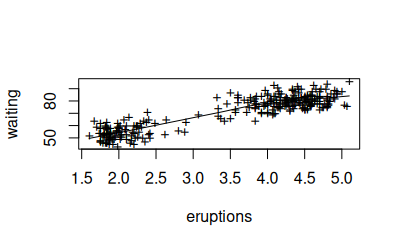

```r
scatter.smooth(eruptions, waiting, pch='+')
```

old faithful data are time series

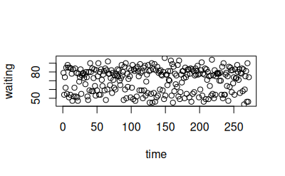

```r
n <- length(waiting)
time <- 1:n

plot(time, waiting)
```

First 100 time points and plot with ‘line’

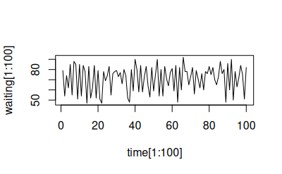

```r
plot(time[1:100], waiting[1:100], type='l')
```

```r
waiting.next <- waiting[-1]
waiting.previous <- waiting[-n]

plot(waiting.previous, waiting.next, pch='+')

abline(h=70, lty=2, col='red')
```

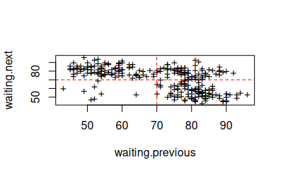

```r
abline(v=70, lty=2, col='red')
```

```r
detach(faithful)
```

# ‘Animals’ data and transformations

```r
library(MASS)
data(Animals)
attach(Animals)
```

```r
summary(body)
```

```
    Min.  1st Qu.   Median     Mean  3rd Qu.     Max.
    0.02     3.10    53.83  4278.44   479.00 87000.00
```

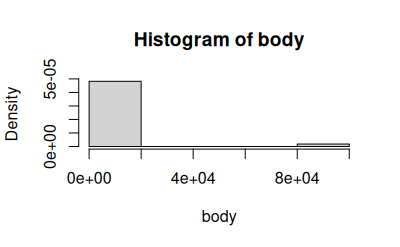

```r
hist(body, prob=TRUE)
```

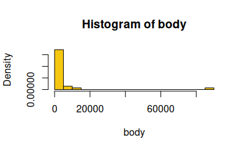

```r
hist(body, breaks=20, prob=TRUE, col=7)
```

Logarithmic transformation

```r
lbody <- log10(body)
summary(lbody)
```

```
   Min. 1st Qu.  Median    Mean 3rd Qu.    Max.
-1.6383  0.4884  1.7308  1.6379  2.6798  4.9395
```

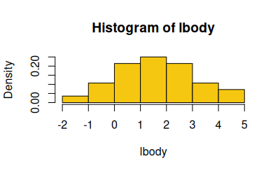

```r
hist(lbody, prob=TRUE, col=7)
```

```r
# Inverse transformation
10^mean(lbody)
```

```
[1] 43.43674
```

```r
summary(body)
```

```
    Min.  1st Qu.   Median     Mean  3rd Qu.     Max.
    0.02     3.10    53.83  4278.44   479.00 87000.00
```

Geometric mean

```r
n <- length(body)
prod(body)^(1/n)
```

[output not shown]

Scatterplot

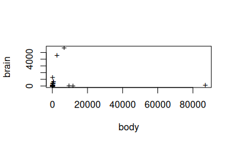

```r
plot(body, brain, pch='+')
```

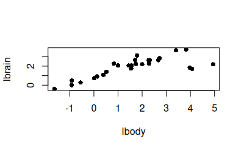

```r
lbrain <- log10(brain)
plot(lbody, lbrain, pch=16)
```